# Herbivorie

Anna Mrazova

2025-03-11

# Used libraries

```r
library(Matrix)
library(lme4)
library(data.table)
library(dplyr)
library(ggplot2)
library(car)
library(rcompanion)
library(emmeans)
library(glmmTMB)
library(MuMIn)
```

# 1: CUMULATIVE HERBIVORY

## Load data

```r
data <- read.csv("C:/Users/annam/OneDrive - Biologické centrum AV ČR, v. v. i/Anawork/Students/Diana Tomandlova/Bakalarka/data/herbivory.csv")
datum_2_data <- data %>% filter(datum == 2)
```

## Visualize data

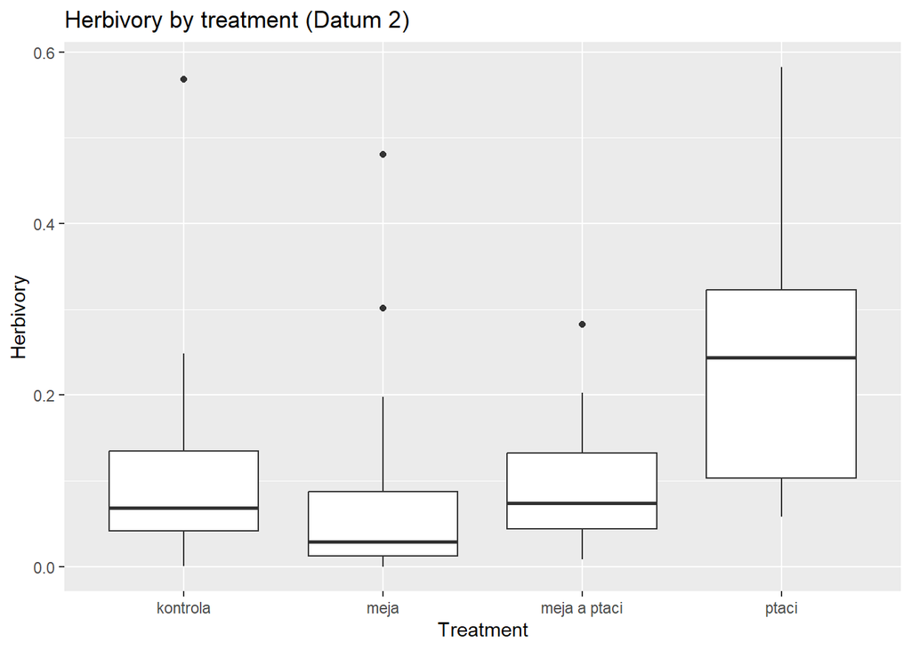

```r
ggplot(datum_2_data, aes(x = treatment, y = herbivorie)) +
  geom_boxplot() +
  labs(title = "Herbivory by treatment (Datum 2)", x = "Treatment", y = "Herbivory")
```

## Data check

```r
shapiro_result <- shapiro.test(datum_2_data$herbivorie)
print(shapiro_result)
```

```
##
##  Shapiro-Wilk normality test
##
## data:  datum_2_data$herbivorie
## W = 0.80751, p-value = 2.088e-07
```

```r
# normality violated -> non-parametric alternative:

kruskal_result <- kruskal.test(herbivorie ~ treatment, data = datum_2_data)
print(kruskal_result)
```

```
##
##  Kruskal-Wallis rank sum test
##
## data:  herbivorie by treatment
## Kruskal-Wallis chi-squared = 14.053, df = 3, p-value = 0.002834
```

### Pairwise Comparisons

```r
pairwise_result <- pairwise.wilcox.test(datum_2_data$herbivorie, datum_2_data$treatment, p.adjust.method = "bonferroni", exact = FALSE)
print(pairwise_result)
```

```
##
##  Pairwise comparisons using Wilcoxon rank sum test with continuity correction
##
## data:  datum_2_data$herbivorie and datum_2_data$treatment
##
##              kontrola meja  meja a ptaci
## meja         1.000    -     -
## meja a ptaci 1.000    0.749 -
## ptaci        0.048    0.013 0.048
##
## P value adjustment method: bonferroni
```

## Cumulative herbivory summary

### Overall explanation

#### The dataset was filtered to use only data corresponding to ‘datum = 2’.

#### A boxplot was created to visualize the distribution of herbivory across different treatments.

#### Normality was checked using the Shapiro-Wilk test.

#### Since the assumptions for parametric tests were violated, a Kruskal-Wallis test was used to assess differences in herbivory across treatments.

#### After finding a significant effect with the Kruskal-Wallis test, pairwise Wilcoxon tests were performed with Bonferroni correction to identify which specific treatment pairs differ significantly.

### Results

#### The pairwise comparisons indicate that the treatment “ptaci” significantly differs from the other treatments (“kontrola”, “meja”, and “meja a ptaci”) in terms of herbivory levels. This suggests that the exclusion of birds (“ptaci”) has a significant effect on herbivory compared to other treatments.

# 2: HERBIVORY DEPENDING ON TIME

## Data filtering

```r
data_grouped <- data %>% group_by(treatment)
```

## Visualization

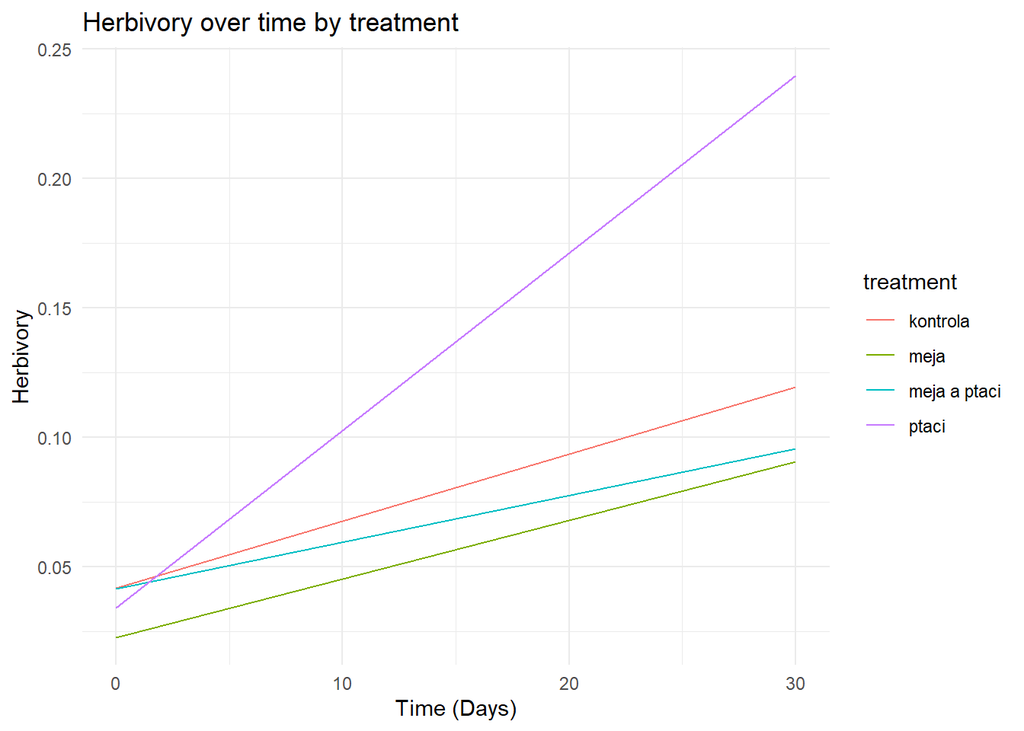

```r
data <- data %>% mutate(day = ifelse(datum == 1, 0, ifelse(datum == 2, 30, NA)))
ggplot(data, aes(x = day, y = herbivorie, color = treatment)) +
  geom_line(stat = "summary", fun = mean) +
  labs(title = "Herbivory over time by treatment", x = "Time (Days)", y = "Herbivory") +
  theme_minimal()
```

## Best model selection

```r
lme_model <- lmer(herbivorie ~ datum * treatment + (1|strom), data = data)

residuals <- residuals(lme_model)
shapiro_result <- shapiro.test(residuals)
print(shapiro_result)
```

```
##
##  Shapiro-Wilk normality test
##
## data:  residuals
## W = 0.86412, p-value = 4.218e-09
```

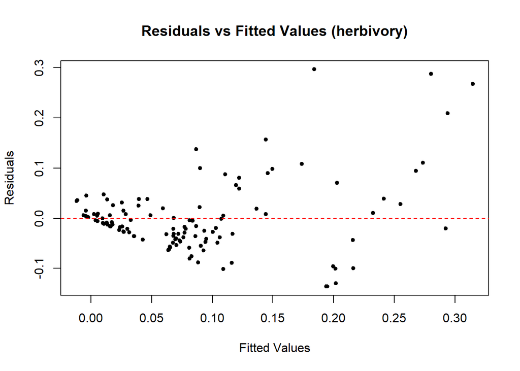

```r
plot(fitted(lme_model), residuals(lme_model),
     main = "Residuals vs Fitted Values (herbivory)",
     xlab = "Fitted Values", ylab = "Residuals", pch = 20)
abline(h = 0, col = "red", lty = 2)
```

```r
# residuals are not normally distributed -> Fit Generalized Linear Mixed-Effects Model (GLMM)

## As Gamma distribution can handle only positive values and we have 0s in our dataset, we will add a small constant (0.001) to all herbivory values to ensure positivity.

data <- data %>% mutate(herbivorie = herbivorie + 0.001)
glmm_model <- glmmTMB(herbivorie ~ day * treatment + (1|strom), data = data, family = Gamma(link = "log"))

residuals_glmm <- residuals(glmm_model, type = "pearson")
shapiro_result_glmm <- shapiro.test(residuals_glmm)
print(shapiro_result_glmm)
```

```
##
##  Shapiro-Wilk normality test
##
## data:  residuals_glmm
## W = 0.94295, p-value = 6.803e-05
```

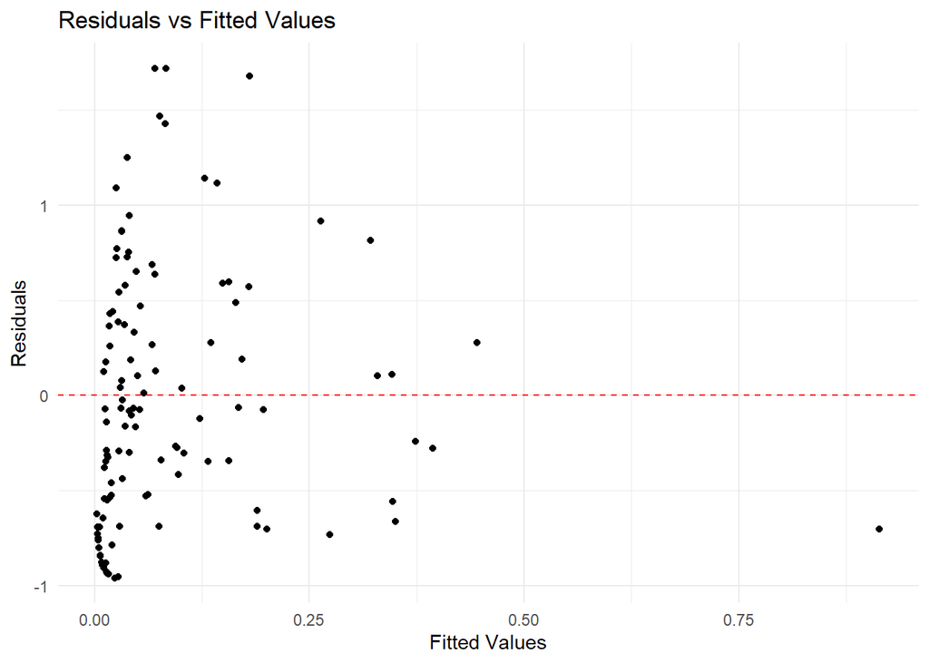

```r
fitted_values <- fitted(glmm_model)
ggplot(data.frame(fitted = fitted_values, residuals = residuals_glmm), aes(x = fitted, y = residuals)) +
  geom_point() +
  geom_hline(yintercept = 0, linetype = "dashed", color = "red") +
  labs(title = "Residuals vs Fitted Values", x = "Fitted Values", y = "Residuals") +
  theme_minimal()
```

```r
# non normal distribution + residuals are spread unevenly

## Fit Generalized Linear Mixed-Effects Model (GLMM) with logit transformation:

# read the data again (to avoid the constan)
data <- read.csv("C:/Users/annam/OneDrive - Biologické centrum AV ČR, v. v. i/Anawork/Students/Diana Tomandlova/Bakalarka/data/herbivory.csv")

# Scale 'herbivorie' values to be strictly between 0 and 1 and apply Logit Transformation
data <- data %>% mutate(herbivorie_scaled = (herbivorie - min(herbivorie)) / (max(herbivorie) - min(herbivorie)) * 0.998 + 0.001)
data <- data %>% mutate(herbivorie_logit = log(herbivorie_scaled / (1 - herbivorie_scaled)))

# Filter data by treatment
data_grouped <- data %>% group_by(treatment)

glmm_model_logit <- glmmTMB(herbivorie_logit ~ datum * treatment + (1 | strom), data = data, family = gaussian(link = "identity"))
print(summary(glmm_model_logit))
```

```
##  Family: gaussian  ( identity )
## Formula:          herbivorie_logit ~ datum * treatment + (1 | strom)
## Data: data
##
##      AIC      BIC   logLik deviance df.resid
##    514.0    541.9   -247.0    494.0      110
##
## Random effects:
##
## Conditional model:
##  Groups   Name        Variance Std.Dev.
##  strom    (Intercept) 1.806    1.344
##  Residual             2.215    1.488
## Number of obs: 120, groups:  strom, 60
##
## Dispersion estimate for gaussian family (sigma^2): 2.22
##
## Conditional model:
##                             Estimate Std. Error z value Pr(>|z|)
## (Intercept)                  -5.3213     0.9268  -5.742 9.36e-09 ***
## datum                         1.7215     0.5435   3.167  0.00154 **
## treatmentmeja                -0.3608     1.3106  -0.275  0.78310
## treatmentmeja a ptaci        -1.6113     1.3106  -1.229  0.21893
## treatmentptaci               -2.7243     1.3106  -2.079  0.03765 *
## datum:treatmentmeja          -0.3211     0.7686  -0.418  0.67613
## datum:treatmentmeja a ptaci   0.7668     0.7686   0.998  0.31843
## datum:treatmentptaci          2.2239     0.7686   2.893  0.00381 **
## ---
## Signif. codes:  0 '***' 0.001 '**' 0.01 '*' 0.05 '.' 0.1 ' ' 1
```

```r
residuals_glmm_logit <- residuals(glmm_model_logit, type = "pearson")
shapiro_result_glmm_logit <- shapiro.test(residuals_glmm_logit)
print(shapiro_result_glmm_logit)
```

```
##
##  Shapiro-Wilk normality test
##
## data:  residuals_glmm_logit
## W = 0.97667, p-value = 0.03501
```

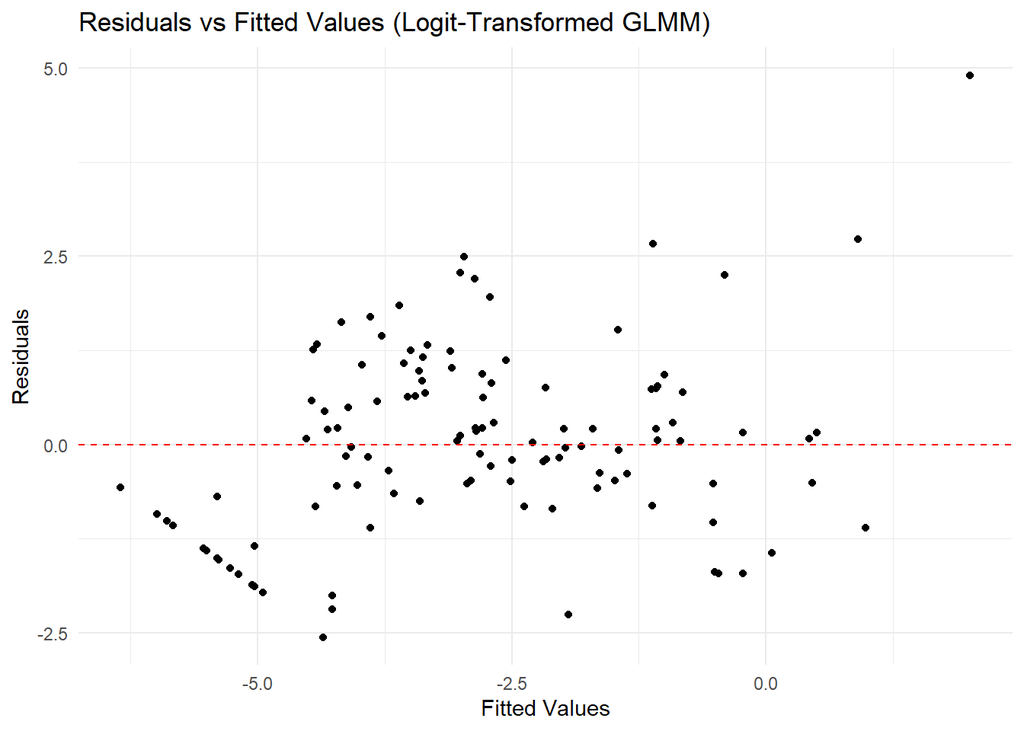

```r
# the data are still not normally distributed. However, the test statistic has improved compared to earlier models, suggesting a partial improvement in residual normality.

# Residuals
fitted_values_logit <- fitted(glmm_model_logit)
ggplot(data.frame(fitted = fitted_values_logit, residuals = residuals_glmm_logit), aes(x = fitted, y = residuals)) +
  geom_point() +
  geom_hline(yintercept = 0, linetype = "dashed", color = "red") +
  labs(title = "Residuals vs Fitted Values (Logit-Transformed GLMM)", x = "Fitted Values", y = "Residuals") +
  theme_minimal()
```

```r
# there is still a visible spread with some clustering and high outliers. # This suggests that the residuals are not perfectly homoscedastic, meaning variance is not entirely constant. However, compared to previous attempts, the residuals appear less skewed, indicating a better fit with the logit-transformed response.
```